# Credit Card Users Churn Prediction

## Observation

- Performance on the logistic regression undersampler performed worse than both the similar to the original and oversampled logistic regression training and validation results.

#### Model 2 - Decision Tree on undersampled data

```python
# Fit the classifier on the undersampled training data
d_tree_under = DecisionTreeClassifier(random_state=1)
d_tree_under.fit(X_train_un, Y_train_un)
```

```
DecisionTreeClassifier(random_state=1)
```

#### Let's check the model performance on train and validation set

```
Training performance:
    Accuracy  Recall  Precision    F1
0     1.000   1.000      1.000 1.000
Validation performance:
    Accuracy  Recall  Precision    F1
0     0.930   0.963      0.955 0.959
```

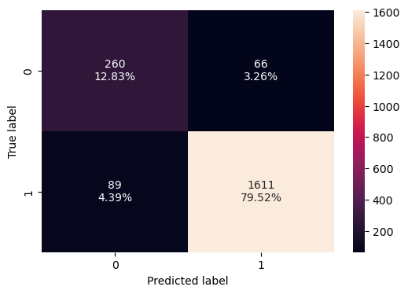

```python
#Calculating different metrics
d_tree_under_model_train_perf=model_performance_classification_sklearn(d_tree_under,X_train_un,Y_train_un)
print("Training performance:\n",d_tree_under_model_train_perf)
d_tree_under_model_val_perf=model_performance_classification_sklearn(d_tree,X_val,Y_val)
print("Validation performance:\n",dtree_model_val_perf)

#Creating confusion matrix
confusion_matrix_sklearn(d_tree, X_val, Y_val)
```

## Observation

- Performance on the decision tree undersampler performed similar to both the original and oversampled decision tree training and validation results.

#### Model 3 - Bagging Classifier on undersampled data

```python
# Create an instance of the BaggingClassifier
bagging_classifier_un = BaggingClassifier(n_estimators=10, random_state=1)

# Fit the bagging classifier on the undersampled data
bagging_classifier_un.fit(X_train_un, Y_train_un)
```

```
BaggingClassifier(random_state=1)
```

#### Let's check the model performance on train and validation set

```
Training performance:
    Accuracy  Recall  Precision    F1
0     0.998   0.996      1.000 0.998
Validation performance:
    Accuracy  Recall  Precision    F1
0     0.953   0.979      0.965 0.972
```

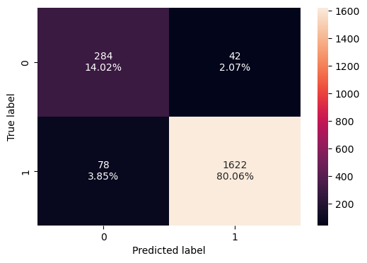

```python
#Calculating different metrics
bagging_classifier_un_model_train_perf=model_performance_classification_sklearn(bagging_classifier_un,X_train_un,Y_train_un)
print("Training performance:\n",bagging_classifier_un_model_train_perf)
bagging_classifier_un_under_model_val_perf=model_performance_classification_sklearn(bagging_classifier_un,X_val,Y_val)
print("Validation performance:\n",bagging_classifier_model_val_perf)

#Creating confusion matrix
confusion_matrix_sklearn(bagging_classifier, X_val, Y_val)
```

## Observation

- Performance on the bagging classifier undersampler performed similar to both the original and oversampled bagging classifier training and validation results.

#### Model 4 - Random Forest on undersampled data

```python
# Create an instance of the Random Forest classifier
random_forest_un = RandomForestClassifier(n_estimators=100, random_state=1)

# Fit the Random Forest classifier on the undersampled data
random_forest_un.fit(X_train_un, Y_train_un)
```

```
RandomForestClassifier(random_state=1)
```

#### Let's check the model performance on train and validation set

```
Training performance:
    Accuracy  Recall  Precision    F1
0     1.000   1.000      1.000 1.000
Validation performance:
    Accuracy  Recall  Precision    F1
0     0.946   0.972      0.964 0.968
```

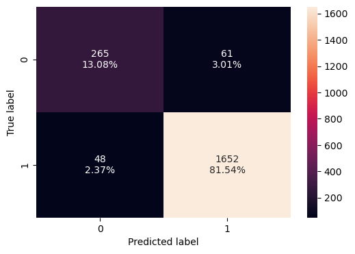

```python
#Calculating different metrics
random_forest_un_model_train_perf=model_performance_classification_sklearn(random_forest_un,X_train_un,Y_train_un)
print("Training performance:\n",random_forest_un_model_train_perf)
rf_classifier_model_val_perf=model_performance_classification_sklearn(rf_classifier,X_val,Y_val)
print("Validation performance:\n",rf_classifier_model_val_perf)

#Creating confusion matrix
confusion_matrix_sklearn(rf_classifier, X_val, Y_val)
```

## Observation

- Performance on the random forest undersampler performed similar to both the original and oversampled random forest training and validation results.

#### Model 5 - AdaBoost Classifier on undersampled data

```python
# Create an instance of the AdaBoost classifier
adaboost_classifier_un = AdaBoostClassifier(n_estimators=100, random_state=1)

# Fit the AdaBoost classifier on the undersampled data
adaboost_classifier_un.fit(X_train_un, Y_train_un)
```

```
AdaBoostClassifier(n_estimators=100, random_state=1)
```

#### Let's check the model performance on train and validation set

```
Training performance:
    Accuracy  Recall  Precision    F1
0     0.962   0.954      0.970 0.962
Validation performance:
    Accuracy  Recall  Precision    F1
0     0.941   0.954      0.975 0.964
```

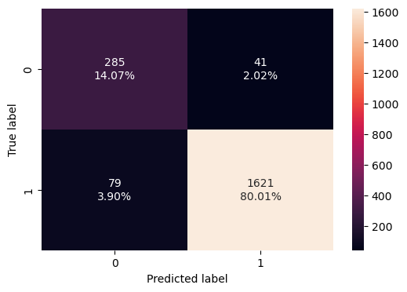

```python
#Calculating different metrics
adaboost_classifier_un_model_train_perf=model_performance_classification_sklearn(adaboost_classifier_un,X_train_un,Y_train_un)
print("Training performance:\n",adaboost_classifier_un_model_train_perf)
adaboost_classifier_model_val_perf=model_performance_classification_sklearn(adaboost_classifier,X_val,Y_val)
print("Validation performance:\n",adaboost_classifier_model_val_perf)

#Creating confusion matrix
confusion_matrix_sklearn(adaboost_classifier, X_val, Y_val)
```

## Observation

- Performance on the AdaBoost Classifier undersampler performed similar to both the original and oversampled AdaBoost Classifier training and validation results.

#### Model 6 - Gradient Boosting Classifier on undersampled data

```python
# Create an instance of the Gradient Boosting classifier
gradient_boosting_un = GradientBoostingClassifier(n_estimators=100, random_state=1)

# Fit the Gradient Boosting classifier on the undersampled data
gradient_boosting_un.fit(X_train_un, Y_train_un)
```

```
GradientBoostingClassifier(random_state=1)
```

#### Let's check the model performance on train set

```python
#Calculating different metrics
gradient_boosting_un_model_train_perf=model_performance_classification_sklearn(gradient_boosting_un,X_train_un,Y_train_un)
print("Training performance:\n",gradient_boosting_un_model_train_perf)
# gradient_boosting_un_model_val_perf=model_performance_classification_sklearn(gradient_boosting,X_val,Y_val)
# print("Validation performance:\n",gradient_boosting_model_un_val_perf)

# #Creating confusion matrix
# confusion_matrix_sklearn(gradient_boosting_un, X_val, Y_val)
```

```
Training performance:
    Accuracy  Recall  Precision    F1
0     0.974   0.972      0.975 0.974
```

## Observation

- Performance on the Gradient Booster Classifier undersampler performed similar to both the original and oversampled Gradient Booster Classifier training and validation results.

```python
# training performance comparison

models_train_comp_df = pd.concat(
    [
        log_reg_model_train_perf.T,
        dtree_model_train_perf.T,
        bagging_classifier_model_train_perf.T,
        rf_estimator_model_train_perf.T,
        ab_classifier_model_train_perf.T,
        gb_classifier_model_train_perf.T,
        log_reg_over_train_perf.T,
        d_tree_train_perf.T,
        bagging_classifier_train_perf.T,
        rf_classifier_train_perf.T,
        adaboost_classifier_train_perf.T,
        gb_classifier_train_perf.T,
        log_reg_under_train_perf.T,
        d_tree_under_model_train_perf.T,
        bagging_classifier_un_model_train_perf.T,
        random_forest_un_model_train_perf.T,
        adaboost_classifier_un_model_train_perf.T,
        gradient_boosting_un_model_train_perf.T
    ],
    axis=1,
)
models_train_comp_df.columns = [
    "Logistic Regression",
    "Decision Tree",
    "Bagging Classifier",
    "Random Forest",
    "AdaBoost Classifier",
    "Gradient Boost Classifier",
    "Logistic Regression with oversampled data",
    "Decision Tree with oversampled data",
    "Bagging Classifier with oversampled data",
    "Random Forest with oversampled data",
    "AdaBoost Classifier with oversampled data",
    "Gradient Boost Classifier with oversampled data",
    "Logistic Regression with undersampled data",
    "Decision Tree with undersampled data",
    "Bagging Classifier with undersampled data",
    "Random Forest with undersampled data",
    "AdaBoost Classifier with undersampled data",
    "Gradient Boost Classifie with undersampled data",
]
print("Training performance comparison:")
models_train_comp_df
```

```
Training performance comparison:
```

|  | Logistic Regression | Decision Tree | Bagging Classifier | Random Forest | AdaBoost Classifier | Gradient Boost Classifier | Logistic Regression with oversampled data | Decision Tree with oversampled data | Bagging Classifier with oversampled data | Random Forest with oversampled data | AdaBoost Classifier with oversampled data | Gradient Boost Classifier with oversampled data | Logistic Regression with undersampled data | Decision Tree with undersampled data | Bagging Classifier with undersampled data | Random Forest with undersampled data | AdaBoost Classifier with undersampled data | Gradient Boost Classifie with undersampled data |
| --- | --- | --- | --- | --- | --- | --- | --- | --- | --- | --- | --- | --- | --- | --- | --- | --- | --- | --- |
| Accuracy | 0.886 | 1.000 | 0.997 | 1.000 | 0.961 | 0.978 | 0.828 | 1.000 | 0.997 | 1.000 | 0.965 | 0.979 | 0.788 | 1.000 | 0.998 | 1.000 | 0.962 | 0.974 |
| Recall | 0.976 | 1.000 | 0.998 | 1.000 | 0.983 | 0.992 | 0.841 | 1.000 | 0.995 | 1.000 | 0.963 | 0.976 | 0.790 | 1.000 | 0.996 | 1.000 | 0.954 | 0.972 |
| Precision | 0.897 | 1.000 | 0.999 | 1.000 | 0.972 | 0.982 | 0.820 | 1.000 | 0.999 | 1.000 | 0.968 | 0.982 | 0.787 | 1.000 | 1.000 | 1.000 | 0.970 | 0.975 |
| F1 | 0.935 | 1.000 | 0.998 | 1.000 | 0.977 | 0.987 | 0.831 | 1.000 | 0.997 | 1.000 | 0.965 | 0.979 | 0.788 | 1.000 | 0.998 | 1.000 | 0.962 | 0.974 |

### HyperparameterTuning

- All 18 models have relatively great recall with no obvious overrfit.
- Logistic regression had the lowest recall in all 3 categories - original, oversampled and undersampled data. Logistics regression with the undersampled data had the lowest recall and was chosen for hyperparameter tuning.
- The other 2 models with the lowest 2 recall scores (excluding logistic regression with original and oversampled data) were also chosen for tuning to see if they can be improved upon.

```python
# defining a function to compute different metrics to check performance of a classification model built using sklearn
def model_performance_classification_sklearn(model, predictors, target):
    """
    Function to compute different metrics to check classification model performance

    model: classifier
    predictors: independent variables
    target: dependent variable
    """

    # predicting using the independent variables
    pred = model.predict(predictors)

    acc = accuracy_score(target, pred)  # to compute Accuracy
    recall = recall_score(target, pred)  # to compute Recall
    precision = precision_score(target, pred)  # to compute Precision
    f1 = f1_score(target, pred)  # to compute F1-score

    # creating a dataframe of metrics
    df_perf = pd.DataFrame(
        {"Accuracy": acc, "Recall": recall, "Precision": precision, "F1": f1,},
        index=[0],
    )

    return df_perf
```

```python
def confusion_matrix_sklearn(model, predictors, target):
    """
    To plot the confusion_matrix with percentages

    model: classifier
    predictors: independent variables
    target: dependent variable
    """
    y_pred = model.predict(predictors)
    cm = confusion_matrix(target, y_pred)
    labels = np.asarray(
        [
            ["{0:0.0f}".format(item) + "\n{0:.2%}".format(item / cm.flatten().sum())]
            for item in cm.flatten()
        ]
    ).reshape(2, 2)

    plt.figure(figsize=(6, 4))
    sns.heatmap(cm, annot=labels, fmt="")
    plt.ylabel("True label")
    plt.xlabel("Predicted label")
```

#### Model 1 for hyperparameter tuning - Logistic Regression on undersampled data

```python
# defining model
Model = LogisticRegression(random_state=1)

# Parameter grid to pass in RandomSearchCV
param_grid = {'C': np.arange(0.1,1.1,0.1)}


#Calling RandomizedSearchCV
randomized_cv = RandomizedSearchCV(estimator=Model, param_distributions=param_grid, n_iter=10, n_jobs = -1, scoring=scorer, cv=5, random_state=1)

#Fitting parameters in RandomizedSearchCV
randomized_cv.fit(X_train_un,Y_train_un)

print("Best parameters are {} with CV score={}:" .format(randomized_cv.best_params_,randomized_cv.best_score_))
```

```
Best parameters are {'C': 0.6} with CV score=0.8237728937728936:
```

```python
# building model with best parameters
lr_tuned = LogisticRegression(C = 0.6)

# Fit the model on training data
lr_tuned.fit(X_train_un, Y_train_un)
```

```
LogisticRegression(C=0.6)
```

```
Training performance:
   Accuracy  Recall  Precision    F1
0     0.788   0.793      0.786 0.789
```

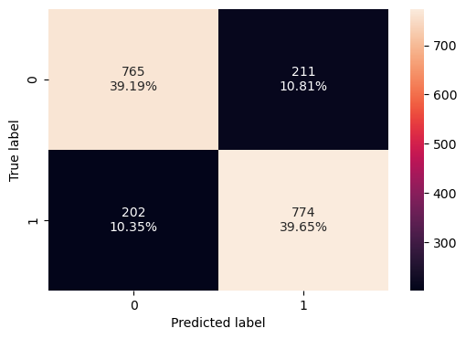

```python
# Calculating different metrics on train set
lr_grid_train = model_performance_classification_sklearn(
    lr_tuned, X_train_un, Y_train_un
)
print("Training performance:")
print(lr_grid_train)

print("*************************************")


# creating confusion matrix
confusion_matrix_sklearn(lr_tuned, X_train_un, Y_train_un)
```

### Observation

- Recall in the training set is similar to that of the undersampled data.
- On comparing the CV score and the training score, model is performing moderately well.
- The validation recall is about 82%.

#### Model 2 for hyperparameter tuning - AdaBoost Classifier on undersampled data

```python
%%time

# defining model
model = AdaBoostClassifier(random_state=1)

# Parameter grid to pass in GridSearchCV

param_grid = {
    "n_estimators": np.arange(10, 110, 10),
    "learning_rate": [0.1, 0.01, 0.2, 0.05, 1],
    "base_estimator": [
        DecisionTreeClassifier(max_depth=1, random_state=1),
        DecisionTreeClassifier(max_depth=2, random_state=1),
        DecisionTreeClassifier(max_depth=3, random_state=1),
    ],
}

# Type of scoring used to compare parameter combinations
scorer = metrics.make_scorer(metrics.recall_score)

# Calling GridSearchCV
grid_cv = GridSearchCV(estimator=model, param_grid=param_grid, scoring=scorer, cv=5, n_jobs = -1)

# Fitting parameters in GridSearchCV
grid_cv.fit(X_train_un, Y_train_un)

print(
    "Best Parameters:{} \nScore: {}".format(grid_cv.best_params_, grid_cv.best_score_)
)
```

```
Best Parameters:{'base_estimator': DecisionTreeClassifier(max_depth=2, random_state=1), 'learning_rate': 1, 'n_estimators': 30}
Score: 0.928262689691261
Wall time: 53.4 s
```

```python
# building model with best parameters
adb_tuned = AdaBoostClassifier(
    n_estimators=30,
    learning_rate=1,
    random_state=1,
    base_estimator=DecisionTreeClassifier(max_depth=2, random_state=1),
)

# Fit the model on training data
adb_tuned.fit(X_train_un, Y_train_un)
```

```
AdaBoostClassifier(base_estimator=DecisionTreeClassifier(max_depth=2,
                                                         random_state=1),
                   learning_rate=1, n_estimators=30, random_state=1)
```

#### Checking model performance

```
Training performance:
   Accuracy  Recall  Precision    F1
0     0.972   0.966      0.977 0.972
```

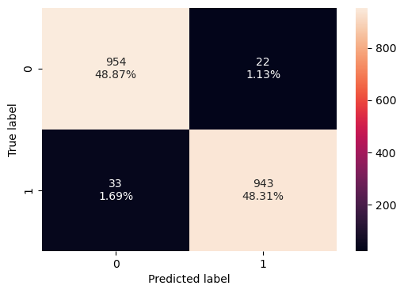

```python
# Calculating different metrics on train set
Adaboost_grid_train = model_performance_classification_sklearn(
    adb_tuned, X_train_un, Y_train_un
)
print("Training performance:")
print(Adaboost_grid_train)

print("*************************************")


# creating confusion matrix
confusion_matrix_sklearn(adb_tuned, X_train_un, Y_train_un)
```

### Observation

- Recall in the training set is now slightly better than in the undersampled data.
- On comparing the CV score and the training score, model is performing well.
- The validation recall is about 92% i.e. the model is good at identifying potential customers for the bank.

#### Model 3 for hyperparameter tuning - Gradient Boosting Classifier on undersampled data

```python
%%time

# defining model
model = GradientBoostingClassifier(random_state=1)

# Parameter grid to pass in GridSearchCV

param_grid = {
    "init": [AdaBoostClassifier(random_state=1),DecisionTreeClassifier(random_state=1)],
    "n_estimators": np.arange(75,150,25),
    "learning_rate": [0.1, 0.01, 0.2, 0.05, 1],
    "subsample":[0.5,0.7,1],
    "max_features":[0.5,0.7,1],
}

# Type of scoring used to compare parameter combinations
scorer = metrics.make_scorer(metrics.recall_score)

# Calling GridSearchCV
grid_cv = GridSearchCV(estimator=model, param_grid=param_grid, scoring=scorer, cv=5, n_jobs = -1)

# Fitting parameters in GridSearchCV
grid_cv.fit(X_train_un, Y_train_un)

print(
    "Best Parameters:{} \nScore: {}".format(grid_cv.best_params_, grid_cv.best_score_)
)
```

```
Best Parameters:{'init': AdaBoostClassifier(random_state=1), 'learning_rate': 0.2, 'max_features': 0.7, 'n_estimators': 125, 'subsample': 0.7}
Score: 0.9405756148613292
Wall time: 1min 40s
```

```python
%%time

# defining model
model = GradientBoostingClassifier(random_state=1)

# Parameter grid to pass in GridSearchCV

param_grid = {
    "init": [GradientBoostingClassifier(random_state=1),DecisionTreeClassifier(random_state=1)],
    "n_estimators": np.arange(75,150,25),
    "learning_rate": [0.1, 0.01, 0.2, 0.05, 1],
    "subsample":[0.5,0.7,1],
    "max_features":[0.5,0.7,1],
}

# Type of scoring used to compare parameter combinations
scorer = metrics.make_scorer(metrics.recall_score)

# Calling GridSearchCV
grid_cv = GridSearchCV(estimator=model, param_grid=param_grid, scoring=scorer, cv=5, n_jobs = -1)

# Fitting parameters in GridSearchCV
grid_cv.fit(X_train_un, Y_train_un)

print(
    "Best Parameters:{} \nScore: {}".format(grid_cv.best_params_, grid_cv.best_score_)
)
```

```
Best Parameters:{'init': GradientBoostingClassifier(random_state=1), 'learning_rate': 0.2, 'max_features': 0.5, 'n_estimators': 75, 'subsample': 0.7}
Score: 0.9446729461015175
Wall time: 2min 12s
```

```python
# building model with best parameters
gb_tuned = GradientBoostingClassifier(
     init = GradientBoostingClassifier(random_state=1),
     n_estimators = 75,
     learning_rate = 0.2,
     subsample = 0.7,
     max_features = 0.5,
)


# Fit the model on training data
gb_tuned.fit(X_train_un, Y_train_un)
```

```
GradientBoostingClassifier(init=GradientBoostingClassifier(random_state=1),
                           learning_rate=0.2, max_features=0.5, n_estimators=75,
                           subsample=0.7)
```

```
Training performance:
   Accuracy  Recall  Precision    F1
0     0.998   0.998      0.999 0.998
```

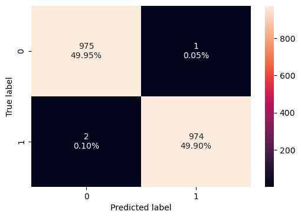

```python
# Calculating different metrics on train set
GradientBoostingClassifier_grid_train = model_performance_classification_sklearn(
    gb_tuned, X_train_un, Y_train_un
)
print("Training performance:")
print(GradientBoostingClassifier_grid_train)

print("*************************************")


# creating confusion matrix
confusion_matrix_sklearn(gb_tuned, X_train_un, Y_train_un)
```

### Observation

- Recall in the training set is now slightly better than in the undersampled data.
- On comparing the CV score and the training score, model is performing well.
- The validation recall is about 94% i.e. the model is good at identifying potential customers for the bank.

## Model Comparison and Final Model Selection

```python
# training performance comparison

models_train_comp_df = pd.concat(
    [
        lr_grid_train.T,
        Adaboost_grid_train.T,
        GradientBoostingClassifier_grid_train.T
    ],
    axis=1,
)
models_train_comp_df.columns = [
    "Logistic regression with undersample Tuned",
    "AdaBoost with undersample Tuned",
    "Gradient classifier with undersample Tuned",
]
print("Training performance comparison:")
models_train_comp_df
```

```
Training performance comparison:
```

|  | Logistic regression with undersample Tuned | AdaBoost with undersample Tuned | Gradient classifier with undersample Tuned |
| --- | --- | --- | --- |
| Accuracy | 0.788 | 0.972 | 0.998 |
| Recall | 0.793 | 0.966 | 0.998 |
| Precision | 0.786 | 0.977 | 0.999 |
| F1 | 0.789 | 0.972 | 0.998 |

### Observation

- Gradient classifier with undersample Tuned gave the better all round results and the highest recall. That is the model we'll use going forward.

### Test set final performance

```python
# Calculating different metrics on the test set
xgboost_grid_test = model_performance_classification_sklearn(xgb_tuned1, X_test, y_test)
print("Test performance:")
xgboost_grid_test
```

```
Training performance:
   Accuracy  Recall  Precision    F1
0     0.957   0.959      0.990 0.974
```

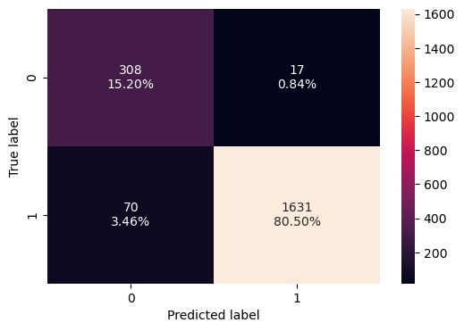

```python
# Calculating different metrics on train set
GradientBoostingClassifier_grid_test = model_performance_classification_sklearn(
    gb_tuned, X_test, Y_test
)
print("Training performance:")
print(GradientBoostingClassifier_grid_test)

print("*************************************")


# creating confusion matrix
confusion_matrix_sklearn(gb_tuned, X_test, Y_test)
```

### Observation

- The recall on the train set is more than ~95%, precision and accuracy are also performing well.

### Feature importance of Tuned Gradient Boosting Classifier with undersampled data

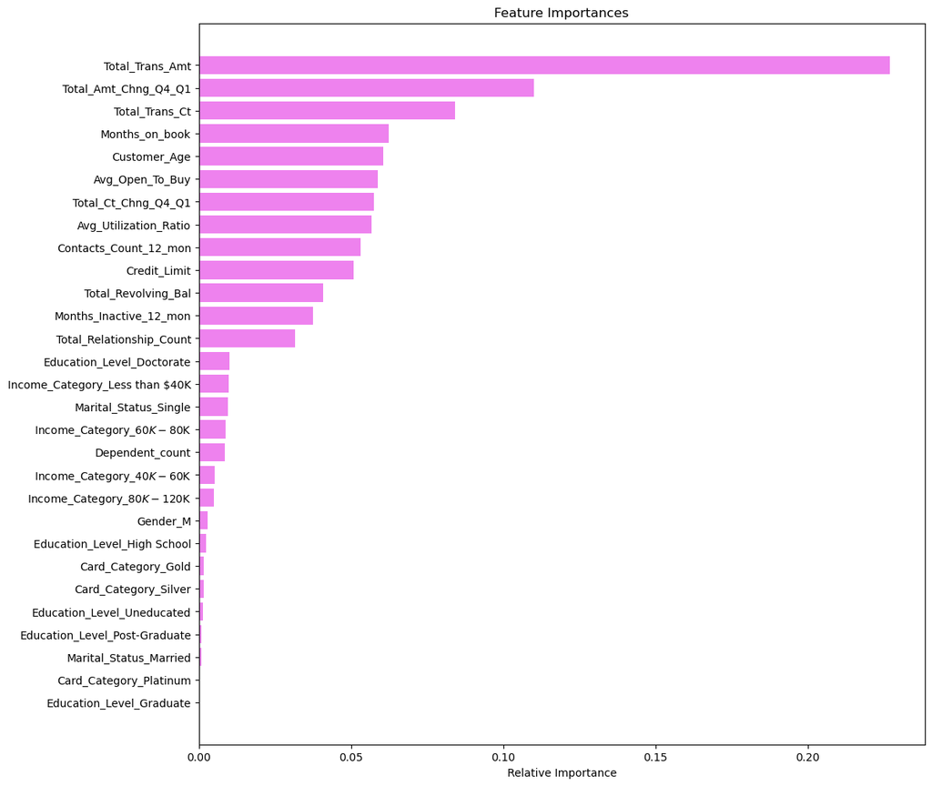

```python
feature_names = X_test.columns
importances = gb_tuned.feature_importances_
indices = np.argsort(importances)

plt.figure(figsize=(12,12))
plt.title('Feature Importances')
plt.barh(range(len(indices)), importances[indices], color='violet', align='center')
plt.yticks(range(len(indices)), [feature_names[i] for i in indices])
plt.xlabel('Relative Importance')
plt.show()
```

### Observation

- `Total_Trans_Amt` is the most important feature for the bank to focus on.

## Pipelines to build the final model

```python
df1 = pd.read_csv("BankChurners_Copy.csv")
```

```python
# Let's convert the columns with an 'object' datatype into categorical variables
for feature in df1.columns: # Loop through all columns in the dataframe
    if df1[feature].dtype == 'object': # Only apply for columns with categorical strings
        df1[feature] = pd.Categorical(df[feature])# Replace strings with an integer
df1.info()
```

```
<class 'pandas.core.frame.DataFrame'>
RangeIndex: 10127 entries, 0 to 10126
Data columns (total 21 columns):
 #   Column                    Non-Null Count  Dtype
---  ------                    --------------  -----
 0   CLIENTNUM                 10127 non-null  int64
 1   Attrition_Flag            10127 non-null  category
 2   Customer_Age              10127 non-null  int64
 3   Gender                    10127 non-null  category
 4   Dependent_count           10127 non-null  int64
 5   Education_Level           8608 non-null   category
 6   Marital_Status            9378 non-null   category
 7   Income_Category           10127 non-null  category
 8   Card_Category             10127 non-null  category
 9   Months_on_book            10127 non-null  int64
 10  Total_Relationship_Count  10127 non-null  int64
 11  Months_Inactive_12_mon    10127 non-null  int64
 12  Contacts_Count_12_mon     10127 non-null  int64
 13  Credit_Limit              10127 non-null  float64
 14  Total_Revolving_Bal       10127 non-null  int64
 15  Avg_Open_To_Buy           10127 non-null  float64
 16  Total_Amt_Chng_Q4_Q1      10127 non-null  float64
 17  Total_Trans_Amt           10127 non-null  int64
 18  Total_Trans_Ct            10127 non-null  int64
 19  Total_Ct_Chng_Q4_Q1       10127 non-null  float64
 20  Avg_Utilization_Ratio     10127 non-null  float64
dtypes: category(6), float64(5), int64(10)
memory usage: 1.2 MB
```

```python
# creating a list of numerical variables
numerical_features = [
     "Customer_Age",
    "Dependent_count",
    "Months_on_book",
    "Total_Relationship_Count",
    "Months_Inactive_12_mon",
    "Contacts_Count_12_mon",
    "Credit_Limit",
    "Total_Revolving_Bal",
    "Avg_Open_To_Buy",
    "Total_Amt_Chng_Q4_Q1",
    "Total_Trans_Amt",
    "Total_Trans_Ct",
    "Total_Ct_Chng_Q4_Q1",
    "Avg_Utilization_Ratio"
]

# creating a transformer for numerical variables, which will apply simple imputer on the numerical variables
numeric_transformer = Pipeline(steps=[("imputer", SimpleImputer(strategy="median"))])


# creating a list of categorical variables
categorical_features = ["Gender", "Education_Level", "Marital_Status", "Income_Category", "Card_Category"]

# creating a transformer for categorical variables, which will first apply simple imputer and
#then do one hot encoding for categorical variables
categorical_transformer = Pipeline(
    steps=[
        ("imputer", SimpleImputer(strategy="most_frequent")),
        ("onehot", OneHotEncoder(handle_unknown="ignore")),
    ]
)
# handle_unknown = "ignore", allows model to handle any unknown category in the test data

# combining categorical transformer and numerical transformer using a column transformer

preprocessor = ColumnTransformer(
    transformers=[
        ("num", numeric_transformer, numerical_features),
        ("cat", categorical_transformer, categorical_features),
    ],
    remainder="passthrough",
)
# remainder = "passthrough" has been used, it will allow variables that are present in original data
# but not in "numerical_columns" and "categorical_columns" to pass through the column transformer without any changes
```

```python
# Let's drop clientum, as it will not add value to the data
df1.drop('CLIENTNUM', axis=1, inplace=True)
```

```python
# Separating target variable and other variables
X = df1.drop(columns="Attrition_Flag")
Y = df1["Attrition_Flag"]
```

- Now we already know the best model we need to process with, so we don't need to divide data into 3 sets - train, validation and test.

```python
df1.head()
```

|  | Attrition_Flag | Customer_Age | Gender | Dependent_count | Education_Level | Marital_Status | Income_Category | Card_Category | Months_on_book | Total_Relationship_Count | Months_Inactive_12_mon | Contacts_Count_12_mon | Credit_Limit | Total_Revolving_Bal | Avg_Open_To_Buy | Total_Amt_Chng_Q4_Q1 | Total_Trans_Amt | Total_Trans_Ct | Total_Ct_Chng_Q4_Q1 | Avg_Utilization_Ratio |
| --- | --- | --- | --- | --- | --- | --- | --- | --- | --- | --- | --- | --- | --- | --- | --- | --- | --- | --- | --- | --- |
| 0 | 1 | 45 | M | 3 | High School | Married | $60K - $80K | Blue | 39 | 5 | 1 | 3 | 12691.000 | 777 | 11914.000 | 1.335 | 1144 | 42 | 1.625 | 0.061 |
| 1 | 1 | 49 | F | 5 | Graduate | Single | Less than $40K | Blue | 44 | 6 | 1 | 2 | 8256.000 | 864 | 7392.000 | 1.541 | 1291 | 33 | 3.714 | 0.105 |
| 2 | 1 | 51 | M | 3 | Graduate | Married | $80K - $120K | Blue | 36 | 4 | 1 | 0 | 3418.000 | 0 | 3418.000 | 2.594 | 1887 | 20 | 2.333 | 0.000 |
| 3 | 1 | 40 | F | 4 | High School | NaN | Less than $40K | Blue | 34 | 3 | 4 | 1 | 3313.000 | 2517 | 796.000 | 1.405 | 1171 | 20 | 2.333 | 0.760 |
| 4 | 1 | 40 | M | 3 | Uneducated | Married | $60K - $80K | Blue | 21 | 5 | 1 | 0 | 4716.000 | 0 | 4716.000 | 2.175 | 816 | 28 | 2.500 | 0.000 |

```python
# Splitting the data into train and test sets
X_train, X_test, Y_train, Y_test = train_test_split(
    X, Y, test_size=0.30, random_state=1, stratify=Y
)
print(X_train.shape, X_test.shape)
```

```
(7088, 19) (3039, 19)
```

```python
# Creating new pipeline with best parameters
model = Pipeline(
    steps=[
        ("pre", preprocessor),
        (
            "GB",
            GradientBoostingClassifier(
               random_state=1,
               n_estimators = 75,
               learning_rate = 0.2,
               subsample = 0.7,
               max_features = 0.5,            ),
        ),
    ]
)
# Fit the model on training data
model.fit(X_train, Y_train)
```

```
Pipeline(steps=[('pre',
                 ColumnTransformer(remainder='passthrough',
                                   transformers=[('num',
                                                  Pipeline(steps=[('imputer',
                                                                   SimpleImputer(strategy='median'))]),
                                                  ['Customer_Age',
                                                   'Dependent_count',
                                                   'Months_on_book',
                                                   'Total_Relationship_Count',
                                                   'Months_Inactive_12_mon',
                                                   'Contacts_Count_12_mon',
                                                   'Credit_Limit',
                                                   'Total_Revolving_Bal',
                                                   'Avg_Open_To_Buy',
                                                   'Total_Amt_Chng_Q4_...
                                                   'Avg_Utilization_Ratio']),
                                                 ('cat',
                                                  Pipeline(steps=[('imputer',
                                                                   SimpleImputer(strategy='most_frequent')),
                                                                  ('onehot',
                                                                   OneHotEncoder(handle_unknown='ignore'))]),
                                                  ['Gender', 'Education_Level',
                                                   'Marital_Status',
                                                   'Income_Category',
                                                   'Card_Category'])])),
                ('GB',
                 GradientBoostingClassifier(learning_rate=0.2, max_features=0.5,
                                            n_estimators=75, random_state=1,
                                            subsample=0.7))])
```

```python
# transforming and predicting on test data
model.predict(X_test)
```

```
array([1, 1, 1, ..., 0, 1, 0], dtype=int64)
```

# Business Insights and Conclusions

- The bank should target customers with high `Total_Trans_Amt`- as these customers are more likely to keep using their credit card.
- The bank should also target customers with high `Total_Amt_Chng_Q4_Q1`, and `Total_Trans_Ct` - as these customer are also likely to keep using their credit card.
- The bank should also target customers with high `Total_Trans_Ct` - as these customer are also likely to keep using their credit card.
- We also observed in our analysis that males are slighly more likely to to keep their accounts open than females.
- That customers with doctorate have the highest number of attrited customers compared to the other education levels.
- That Customers with Platinum credit cards have highest number of attrited customers compared to the other credit card categories.